# Auto Premium Prediction

# Step1: Load the Insurance dataset into R

# Step2: Explore the auto_insurance dataset

```r
str(auto_insurance)
```

```
## 'data.frame':    1338 obs. of  6 variables:
##  $ gender        : chr  "male" "male" "female" "female" ...
##  $ annual_mileage: int  4000 4000 4000 4000 4000 4000 4000 4000 4000 41000 ...
##  $ number_of_DUI : int  0 0 0 0 0 0 0 0 0 6 ...
##  $ credit_score  : int  850 850 850 850 850 781 781 850 781 601 ...
##  $ region        : chr  "southeast" "southeast" "northeast" "northeast" ...
##  $ premium_amount: int  1726 1137 2198 3393 2211 34303 21345 1706 15518 10215 ...
```

##### Through this oberservation we know we have 6 variables and 1338 observations

# Step 2.1 Distributions of the variable

##### I believe linear regression model will fits best for this data set becuase it seems as the premium charges is a depent variable based upon other variables in the dataset.

```r
summary(auto_insurance$premium_amount)
```

```
##    Min. 1st Qu.  Median    Mean 3rd Qu.    Max.
##    1122    4740    9382   13270   16640   63770
```

##### Something to note is that the median value is quite less than meanu value. Which means their is a right skew in distribution of premium_amount. We can take a look at the histogram to better understand the premium_distrubution.

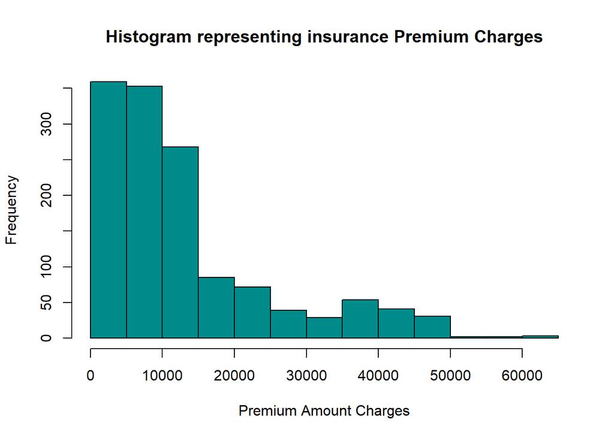

```r
## plotting histogram for premium cost variable
hist(auto_insurance$premium_amount, xlab="Premium Amount Charges" , main="Histogram representing insurance Premium Charges", col="cyan4")
```

##### From the histogram premium we can tell that most of the polocies pay premium of less $30000 and very few that pay more then 60000. Let’s look at the distribut in a normalized view below.

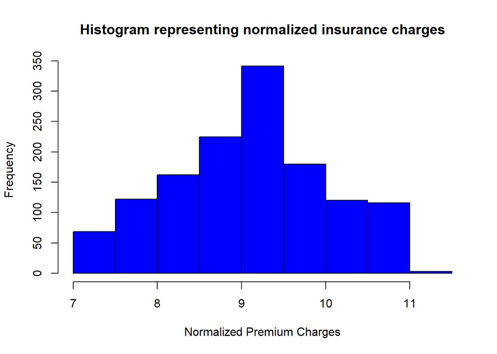

```r
## creating normalized plot using log transformation
auto_insurance$n_charges = log(auto_insurance$premium_amount)

## plotting normalized histogram for insurance premium
hist(auto_insurance$n_charges,xlab="Normalized Premium Charges" ,
     main="Histogram representing normalized insurance charges", col="blue")
```

##### Now that we know the distribution of premium amount lets look at the distribution for gender and region

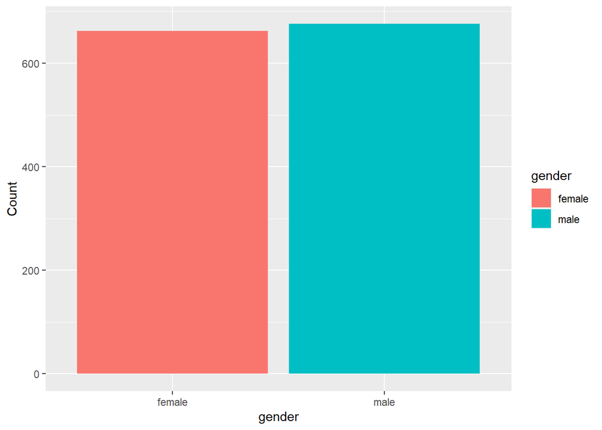

```r
ggplot(as.data.frame(table(auto_insurance["gender"])), aes(x=Var1, y=Freq, fill=Var1)) +
  geom_bar(stat = "identity") + labs(x = "gender", y="Count", fill = "gender")
```

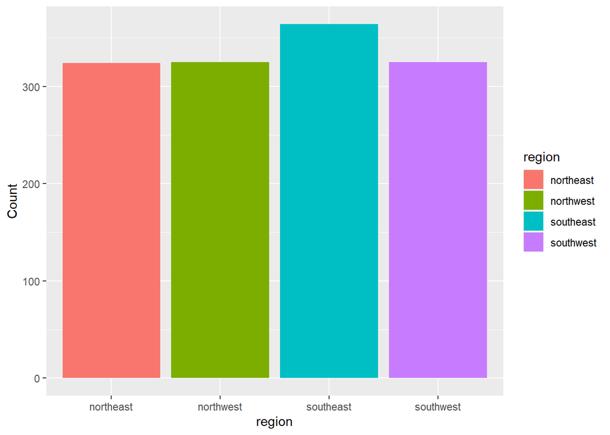

```r
ggplot(as.data.frame(table(auto_insurance["region"])), aes(x=Var1, y=Freq, fill=Var1)) +
  geom_bar(stat = "identity") + labs(x = "region", y="Count", fill = "region")
```

##### From this we can see that our categorical variables gendar and region are evenly distributed.

# Step 2.2 Let’s now look at the correlation between the variables

```r
#Correlation between the variables
cor(auto_insurance[c("annual_mileage", "number_of_DUI", "credit_score", "premium_amount")])
```

```
##                annual_mileage number_of_DUI credit_score premium_amount
## annual_mileage      1.0000000     0.9555423   -0.8342214      0.2989352
## number_of_DUI       0.9555423     1.0000000   -0.8885649      0.4044326
## credit_score       -0.8342214    -0.8885649    1.0000000     -0.6001739
## premium_amount      0.2989352     0.4044326   -0.6001739      1.0000000
```

##### From the correlation we do see that there is a moderately uphill positive correlation between the annual mileage, number_of_DUI and premium amount. We also see a moderate downhill negative relationship between credit_score and premium amount.

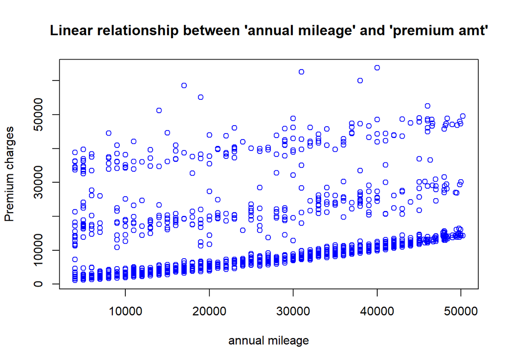

```r
#First, let's take a look at the relationship between mileage drive per year and premium amt.
plot(auto_insurance$annual_mileage , auto_insurance$premium_amount, main="Linear relationship between 'annual mileage' and 'premium amt'", xlab="annual mileage", ylab="Premium charges", col="blue")
```

##### From this we can tell it’s a linear relationship. As the annual mileage increase so does the premium charges.

##### Let’s looks at the pairwise scatterplots and see what correlation we find.

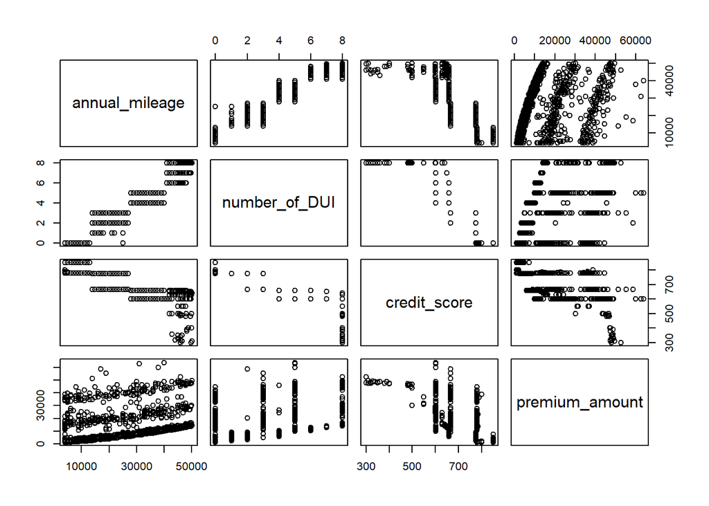

```r
pairs(auto_insurance[c("annual_mileage", "number_of_DUI", "credit_score", "premium_amount")])
```

# Step3: Train a regression model on the insurance data

```r
insurance_model <- lm(data = auto_insurance, formula = premium_amount ~ gender + annual_mileage + number_of_DUI + credit_score
                    + region  )
insurance_model
```

```
##
## Call:
## lm(formula = premium_amount ~ gender + annual_mileage + number_of_DUI +
##     credit_score + region, data = auto_insurance)
##
## Coefficients:
##     (Intercept)       gendermale   annual_mileage    number_of_DUI
##      121183.777          753.443           -0.705         1080.907
##    credit_score  regionnorthwest  regionsoutheast  regionsouthwest
##        -131.973          -68.138         1230.737         -581.765
```

```r
summary(insurance_model)
```

```
##
## Call:
## lm(formula = premium_amount ~ gender + annual_mileage + number_of_DUI +
##     credit_score + region, data = auto_insurance)
##
## Residuals:
##    Min     1Q Median     3Q    Max
## -16272  -5782  -1108   3194  43466
##
## Coefficients:
##                   Estimate Std. Error t value Pr(>|t|)
## (Intercept)      1.212e+05  4.297e+03  28.205  < 2e-16 ***
## gendermale       7.534e+02  4.699e+02   1.604  0.10905
## annual_mileage  -7.050e-01  5.717e-02 -12.331  < 2e-16 ***
## number_of_DUI    1.081e+03  3.802e+02   2.843  0.00454 **
## credit_score    -1.320e+02  5.212e+00 -25.319  < 2e-16 ***
## regionnorthwest -6.814e+01  6.738e+02  -0.101  0.91946
## regionsoutheast  1.231e+03  6.553e+02   1.878  0.06057 .
## regionsouthwest -5.818e+02  6.740e+02  -0.863  0.38819
## ---
## Signif. codes:  0 '***' 0.001 '**' 0.01 '*' 0.05 '.' 0.1 ' ' 1
##
## Residual standard error: 8575 on 1330 degrees of freedom
## Multiple R-squared:  0.5012, Adjusted R-squared:  0.4986
## F-statistic: 190.9 on 7 and 1330 DF,  p-value: < 2.2e-16
```

##### Coefficients of gendermale, number_of_DUI and regionsoutheast are postively related to premium_amount. While annual_mileage, credit_score and regionnorthwest are negatively relate to the premium_amount.

##### For each year of increase in number_of_DUI the premium value is expected to increase by 1081. Like wise if the insured person is male the premium value are up by 753 considering with other variable. If the person lives in the region southeast we the premium value to by 1231. If the premium value is good then we see decline in premium value by 132 and if the person lives in the regionnorthwest we see the premium value to be decrease by 68.

```r
summary(insurance_model)
```

```
##
## Call:
## lm(formula = premium_amount ~ gender + annual_mileage + number_of_DUI +
##     credit_score + region, data = auto_insurance)
##
## Residuals:
##    Min     1Q Median     3Q    Max
## -16272  -5782  -1108   3194  43466
##
## Coefficients:
##                   Estimate Std. Error t value Pr(>|t|)
## (Intercept)      1.212e+05  4.297e+03  28.205  < 2e-16 ***
## gendermale       7.534e+02  4.699e+02   1.604  0.10905
## annual_mileage  -7.050e-01  5.717e-02 -12.331  < 2e-16 ***
## number_of_DUI    1.081e+03  3.802e+02   2.843  0.00454 **
## credit_score    -1.320e+02  5.212e+00 -25.319  < 2e-16 ***
## regionnorthwest -6.814e+01  6.738e+02  -0.101  0.91946
## regionsoutheast  1.231e+03  6.553e+02   1.878  0.06057 .
## regionsouthwest -5.818e+02  6.740e+02  -0.863  0.38819
## ---
## Signif. codes:  0 '***' 0.001 '**' 0.01 '*' 0.05 '.' 0.1 ' ' 1
##
## Residual standard error: 8575 on 1330 degrees of freedom
## Multiple R-squared:  0.5012, Adjusted R-squared:  0.4986
## F-statistic: 190.9 on 7 and 1330 DF,  p-value: < 2.2e-16
```

# Step 4: Testing different Senarios

```r
predict(insurance_model, data.frame(gender = c("male", "female", "male"), annual_mileage = c(6000, 5100, 1000 ), number_of_DUI = c(8,1,0), credit_score = c(300, 661, 850), region = c("southwest", "southwest", "southwest" ) ) )
```

```
##         1         2         3
## 86181.050 30853.633  8473.772
```

```r
predict(insurance_model, data.frame(gender = c("male"), annual_mileage = c(6000 ), number_of_DUI = c(8), credit_score = c(300), region = c("southwest" ) ) )
```

```
##        1
## 86181.05
```

```r
predict(insurance_model, data.frame(gender = c( "female"), annual_mileage = c(5100 ), number_of_DUI = c(1), credit_score = c( 661), region = c( "southwest" ) ) )
```

```
##        1
## 30853.63
```

```r
predict(insurance_model, data.frame(gender = c("male"), annual_mileage = c( 1000 ), number_of_DUI = c(0), credit_score = c( 850), region = c( "southwest" ) ) )
```

```
##        1
## 8473.772
```